# M05-2 Application: Data Wrangling with Tidyverse in R

Author

Alexandria Jaimes

Published

June 29, 2026

# 1 Overview

This codebook is for my M05-2 Application Assignment on data wrangling with Tidyverse in R. For this assignment, I’m using different Tidyverse functions to work with the datasets and answer each question.

# 2 Setup

This setup chunk loads the packages needed for the assignment.

```r
# Load packages
library(tidyverse)
library(nycflights13)
library(gt)
library(gtExtras)
```

# 3 Exercise 1

## 3.1 1.1 Convert airquality to a tibble and data frame

**Question:** Now, using the Tidyverse library, set the built-in `airquality` dataset to a tibble format named `air.tib`. Confirm that the operation was successful. Next, create a new data frame from `air.tib` and assign `air.df` to the data frame. Confirm that the operation was successful.

```r
# Convert airquality to a tibble
air.tib <- as_tibble(airquality)

# Print the tibble to confirm it worked
air.tib
```

| Ozone | Solar.R | Wind | Temp | Month | Day |
| --- | --- | --- | --- | --- | --- |
| 41 | 190 | 7.4 | 67 | 5 | 1 |
| 36 | 118 | 8.0 | 72 | 5 | 2 |
| 12 | 149 | 12.6 | 74 | 5 | 3 |
| 18 | 313 | 11.5 | 62 | 5 | 4 |
| NA | NA | 14.3 | 56 | 5 | 5 |
| 28 | NA | 14.9 | 66 | 5 | 6 |
| 23 | 299 | 8.6 | 65 | 5 | 7 |
| 19 | 99 | 13.8 | 59 | 5 | 8 |
| 8 | 19 | 20.1 | 61 | 5 | 9 |
| NA | 194 | 8.6 | 69 | 5 | 10 |

[output cut: 143 more lines]

```r
# Create a data frame from the tibble
air.df <- as.data.frame(air.tib)

# Print the data frame to confirm it worked
air.df
```

| Ozone | Solar.R | Wind | Temp | Month | Day |
| --- | --- | --- | --- | --- | --- |
| 41 | 190 | 7.4 | 67 | 5 | 1 |
| 36 | 118 | 8.0 | 72 | 5 | 2 |
| 12 | 149 | 12.6 | 74 | 5 | 3 |
| 18 | 313 | 11.5 | 62 | 5 | 4 |
| NA | NA | 14.3 | 56 | 5 | 5 |
| 28 | NA | 14.9 | 66 | 5 | 6 |
| 23 | 299 | 8.6 | 65 | 5 | 7 |
| 19 | 99 | 13.8 | 59 | 5 | 8 |
| 8 | 19 | 20.1 | 61 | 5 | 9 |
| NA | 194 | 8.6 | 69 | 5 | 10 |

[output cut: 143 more lines]

## 3.2 1.2 Find Ozone when Temp is 97

**Question:** Using the tibble created earlier, find the Ozone amount when the temperature was 97. Show this by subsetting the entire row and pinpointing the Ozone element only. Use both Base R and Tidyverse approaches.

```r
# Base R: subset the entire row where Temp is 97
air.tib[air.tib$Temp == 97, ]
```

| Ozone | Solar.R | Wind | Temp | Month | Day |
| --- | --- | --- | --- | --- | --- |
| 76 | 203 | 9.7 | 97 | 8 | 28 |

```r
# Base R: pinpoint the Ozone value only
air.tib$Ozone[air.tib$Temp == 97]
```

```
[1] 76
```

```r
# Tidyverse: subset the entire row where Temp is 97
air.tib |>
  filter(Temp == 97)
```

| Ozone | Solar.R | Wind | Temp | Month | Day |
| --- | --- | --- | --- | --- | --- |
| 76 | 203 | 9.7 | 97 | 8 | 28 |

```r
# Tidyverse: pinpoint the Ozone value only
air.tib |>
  filter(Temp == 97) |>
  pull(Ozone)
```

```
[1] 76
```

# 4 Exercise 2

## 4.1 2.1 Worst arrival delays and monthly average delay

**Question:** Using the `flights` data, select the top 10 worst arrival delays for each day, month, and year. From that subset, calculate the average delay for each month regardless of dates and years.

```r
# Load package and flights dataset
library(nycflights13)
data("flights")

# Find the top 10 worst arrival delays for each day
worst_daily_delays <- flights |>
  group_by(year, month, day) |>
  arrange(desc(arr_delay), .by_group = TRUE) |>
  slice_head(n = 10) |>
  ungroup()
# Print results to confirm it worked
worst_daily_delays
```

| year | month | day | dep_time | sched_dep_time | dep_delay | arr_time | sched_arr_time | arr_delay | carrier | flight | tailnum | origin | dest | air_time | distance | hour | minute | time_hour |
| --- | --- | --- | --- | --- | --- | --- | --- | --- | --- | --- | --- | --- | --- | --- | --- | --- | --- | --- |
| 2013 | 1 | 1 | 848 | 1835 | 853 | 1001 | 1950 | 851 | MQ | 3944 | N942MQ | JFK | BWI | 41 | 184 | 18 | 35 | 2013-01-01 18:00:00 |
| 2013 | 1 | 1 | 2343 | 1724 | 379 | 314 | 1938 | 456 | EV | 4321 | N21197 | EWR | MCI | 222 | 1092 | 17 | 24 | 2013-01-01 17:00:00 |
| 2013 | 1 | 1 | 1815 | 1325 | 290 | 2120 | 1542 | 338 | EV | 4417 | N17185 | EWR | OMA | 213 | 1134 | 13 | 25 | 2013-01-01 13:00:00 |
| 2013 | 1 | 1 | 1842 | 1422 | 260 | 1958 | 1535 | 263 | EV | 4633 | N18120 | EWR | BTV | 46 | 266 | 14 | 22 | 2013-01-01 14:00:00 |
| 2013 | 1 | 1 | 2115 | 1700 | 255 | 2330 | 1920 | 250 | 9E | 3347 | N924XJ | JFK | CVG | 115 | 589 | 17 | 0 | 2013-01-01 17:00:00 |
| 2013 | 1 | 1 | 2205 | 1720 | 285 | 46 | 2040 | 246 | AA | 1999 | N5DNAA | EWR | MIA | 146 | 1085 | 17 | 20 | 2013-01-01 17:00:00 |
| 2013 | 1 | 1 | 2006 | 1630 | 216 | 2230 | 1848 | 222 | EV | 4644 | N14972 | EWR | SAV | 121 | 708 | 16 | 30 | 2013-01-01 16:00:00 |
| 2013 | 1 | 1 | 2312 | 2000 | 192 | 21 | 2110 | 191 | EV | 4312 | N13958 | EWR | DCA | 44 | 199 | 20 | 0 | 2013-01-01 20:00:00 |
| 2013 | 1 | 1 | 1942 | 1705 | 157 | 2124 | 1830 | 174 | MQ | 4410 | N835MQ | JFK | DCA | 60 | 213 | 17 | 5 | 2013-01-01 17:00:00 |
| 2013 | 1 | 1 | 1938 | 1703 | 155 | 2109 | 1823 | 166 | EV | 4300 | N18557 | EWR | RIC | 68 | 277 | 17 | 3 | 2013-01-01 17:00:00 |

[output cut: 3640 more lines]

```r
# Calculate average delay for each month from the worst daily delays
monthly_avg_delay <- worst_daily_delays |>
  group_by(month) |>
  summarize(avg_arr_delay = mean(arr_delay, na.rm = TRUE)) |>
  arrange(month)

# Print monthly average delay
monthly_avg_delay
```

| month | avg_arr_delay |
| --- | --- |
| 1 | 200.0161 |
| 2 | 198.6214 |
| 3 | 202.1194 |
| 4 | 220.4000 |
| 5 | 201.6613 |
| 6 | 249.4167 |
| 7 | 254.1290 |
| 8 | 194.8839 |
| 9 | 166.0233 |
| 10 | 161.4903 |

[output cut: 2 more lines]

## 4.2 2.2 Visualize average arrival delays by month

**Question:** Visualize the average arrival delays for each month with a presentable chart.

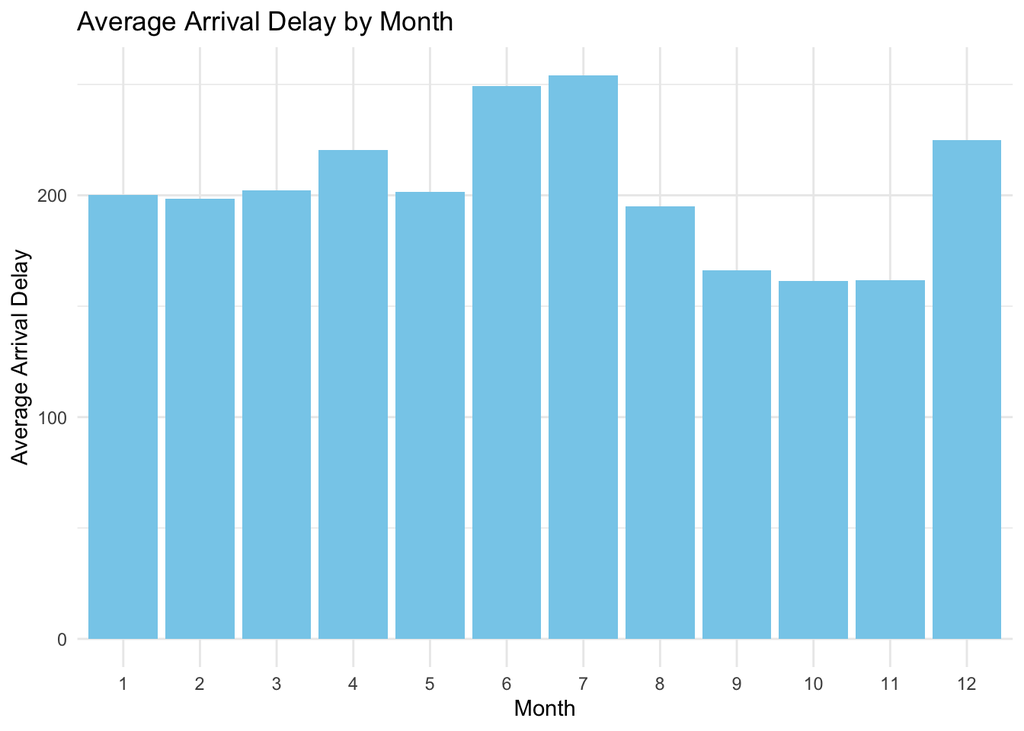

```r
# Create a chart of average arrival delays by month
monthly_avg_delay |>
  ggplot(aes(x = factor(month), y = avg_arr_delay)) +
  geom_col(fill = "skyblue") +
  labs(
    title = "Average Arrival Delay by Month",
    x = "Month",
    y = "Average Arrival Delay"
  ) +
  theme_minimal()
```

I changed the bar chart color by adding `fill = "skyblue"` inside `geom_col()`. This makes the visualization easier to read and more appealing while still keeping the chart simple.

## 4.3 2.3 Describe what you learned about delays

The chart shows that some months had higher average arrival delays than others. I think this could be because of things like weather, airport traffic, or busy travel seasons. It shows me that delays don’t happen evenly across the whole year.

# 5 Exercise 3

## 5.1 3.1 Inspect the relig_income data

**Question:** Inspect the `relig_income` data using built-in functions for type, size, missing values, variables, and other basic information.

```r
# Inspect the relig_income dataset
relig_income
```

| religion | <$10k | $10-20k | $20-30k | $30-40k | $40-50k | $50-75k | $75-100k | $100-150k | >150k | Don't know/refused |
| --- | --- | --- | --- | --- | --- | --- | --- | --- | --- | --- |
| Agnostic | 27 | 34 | 60 | 81 | 76 | 137 | 122 | 109 | 84 | 96 |
| Atheist | 12 | 27 | 37 | 52 | 35 | 70 | 73 | 59 | 74 | 76 |
| Buddhist | 27 | 21 | 30 | 34 | 33 | 58 | 62 | 39 | 53 | 54 |
| Catholic | 418 | 617 | 732 | 670 | 638 | 1116 | 949 | 792 | 633 | 1489 |
| Don’t know/refused | 15 | 14 | 15 | 11 | 10 | 35 | 21 | 17 | 18 | 116 |
| Evangelical Prot | 575 | 869 | 1064 | 982 | 881 | 1486 | 949 | 723 | 414 | 1529 |
| Hindu | 1 | 9 | 7 | 9 | 11 | 34 | 47 | 48 | 54 | 37 |
| Historically Black Prot | 228 | 244 | 236 | 238 | 197 | 223 | 131 | 81 | 78 | 339 |
| Jehovah's Witness | 20 | 27 | 24 | 24 | 21 | 30 | 15 | 11 | 6 | 37 |
| Jewish | 19 | 19 | 25 | 25 | 30 | 95 | 69 | 87 | 151 | 162 |

[output cut: 8 more lines]

```r
# Check the structure of the data
str(relig_income)
```

```
tibble [18 × 11] (S3: tbl_df/tbl/data.frame)
 $ religion          : chr [1:18] "Agnostic" "Atheist" "Buddhist" "Catholic" ...
 $ <$10k             : num [1:18] 27 12 27 418 15 575 1 228 20 19 ...
 $ $10-20k           : num [1:18] 34 27 21 617 14 869 9 244 27 19 ...
 $ $20-30k           : num [1:18] 60 37 30 732 15 ...
 $ $30-40k           : num [1:18] 81 52 34 670 11 982 9 238 24 25 ...
 $ $40-50k           : num [1:18] 76 35 33 638 10 881 11 197 21 30 ...
 $ $50-75k           : num [1:18] 137 70 58 1116 35 ...
 $ $75-100k          : num [1:18] 122 73 62 949 21 949 47 131 15 69 ...
 $ $100-150k         : num [1:18] 109 59 39 792 17 723 48 81 11 87 ...
 $ >150k             : num [1:18] 84 74 53 633 18 414 54 78 6 151 ...
 $ Don't know/refused: num [1:18] 96 76 54 1489 116 ...
```

```r
# Check the size of the data
dim(relig_income)
```

```
[1] 18 11
```

```r
# Check variable names
names(relig_income)
```

```
 [1] "religion"           "<$10k"              "$10-20k"
 [4] "$20-30k"            "$30-40k"            "$40-50k"
 [7] "$50-75k"            "$75-100k"           "$100-150k"
[10] ">150k"              "Don't know/refused"
```

```r
# Count missing values in each column
colSums(is.na(relig_income))
```

```
          religion              <$10k            $10-20k            $20-30k
                 0                  0                  0                  0
           $30-40k            $40-50k            $50-75k           $75-100k
                 0                  0                  0                  0
         $100-150k              >150k Don't know/refused
                 0                  0                  0
```

The `relig_income` data has religion groups in rows and income ranges in columns. I checked the structure, size, variable names, and missing values before changing the shape of the data.

## 5.2 3.2 Describe the relig_income data

**Question:** Use the help page for `relig_income` and explain what the data and variables represent.

This data shows different religions and how many people fall into each income group. The religion names are in the first column, and the rest of the columns are income ranges. It helps me see how income is spread out across each religion group.

## 5.3 3.3 Explain if the data is tidy

**Question:** Explain whether the current data is tidy for visualizing the count of income brackets by religion.

The data isn’t fully tidy for this kind of chart because the income groups are spread across different columns. It would be easier to graph if the income ranges were in one column and the counts were in another column.

## 5.4 3.4 Reshape and visualize relig_income

**Question:** Reshape the data so it has columns for religion, income, and count. Then visualize the income distribution by religion.

```r
# Reshape relig_income from wide to long
relig_income_longer <- relig_income |>
  pivot_longer(
    cols = -religion,
    names_to = "income",
    values_to = "count"
  )

# Print the reshaped data
relig_income_longer
```

| religion | income | count |
| --- | --- | --- |
| Agnostic | <$10k | 27 |
| Agnostic | $10-20k | 34 |
| Agnostic | $20-30k | 60 |
| Agnostic | $30-40k | 81 |
| Agnostic | $40-50k | 76 |
| Agnostic | $50-75k | 137 |
| Agnostic | $75-100k | 122 |
| Agnostic | $100-150k | 109 |
| Agnostic | >150k | 84 |
| Agnostic | Don't know/refused | 96 |

[output cut: 170 more lines]

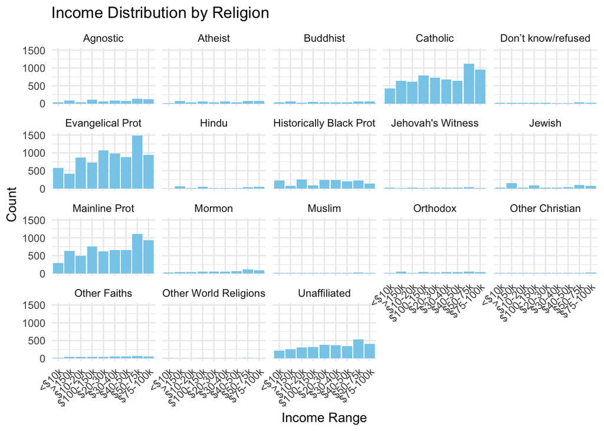

```r
# Visualize income distribution by religion
relig_income_longer |>
  filter(income != "Don't know/refused") |>
  ggplot(aes(x = income, y = count)) +
  geom_col(fill = "skyblue") +
  facet_wrap(~ religion) +
  labs(
    title = "Income Distribution by Religion",
    x = "Income Range",
    y = "Count"
  ) +
  theme_minimal() +
  theme(axis.text.x = element_text(angle = 45, hjust = 1))
```

## 5.5 3.5 Reshape and visualize in one chain

**Question:** Redo the reshaping and visualization in one long Tidyverse chain.

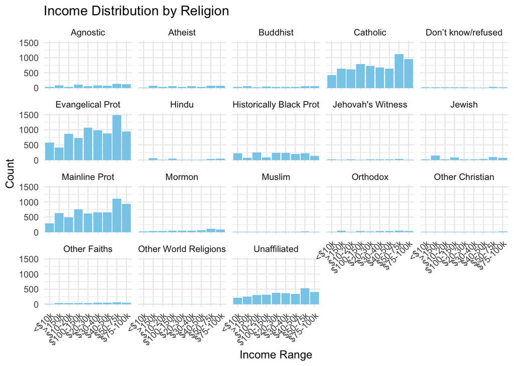

```r
# Reshape and visualize relig_income in one chain
relig_income |>
  pivot_longer(
    cols = -religion,
    names_to = "income",
    values_to = "count"
  ) |>
  filter(income != "Don't know/refused") |>
  ggplot(aes(x = income, y = count)) +
  geom_col(fill = "skyblue") +
  facet_wrap(~ religion) +
  labs(
    title = "Income Distribution by Religion",
    x = "Income Range",
    y = "Count"
  ) +
  theme_minimal() +
  theme(axis.text.x = element_text(angle = 45, hjust = 1))
```

# 6 Exercise 4

## 6.1 4.1 Inspect the us_rent_income data

**Question:** Inspect the `us_rent_income` data using built-in functions for type, size, missing values, variables, and other basic information.

```r
# Inspect the us_rent_income dataset
us_rent_income
```

| GEOID | NAME | variable | estimate | moe |
| --- | --- | --- | --- | --- |
| 01 | Alabama | income | 24476 | 136 |
| 01 | Alabama | rent | 747 | 3 |
| 02 | Alaska | income | 32940 | 508 |
| 02 | Alaska | rent | 1200 | 13 |
| 04 | Arizona | income | 27517 | 148 |
| 04 | Arizona | rent | 972 | 4 |
| 05 | Arkansas | income | 23789 | 165 |
| 05 | Arkansas | rent | 709 | 5 |
| 06 | California | income | 29454 | 109 |
| 06 | California | rent | 1358 | 3 |

[output cut: 94 more lines]

```r
# Check the structure of the data
str(us_rent_income)
```

```
tibble [104 × 5] (S3: tbl_df/tbl/data.frame)
 $ GEOID   : chr [1:104] "01" "01" "02" "02" ...
 $ NAME    : chr [1:104] "Alabama" "Alabama" "Alaska" "Alaska" ...
 $ variable: chr [1:104] "income" "rent" "income" "rent" ...
 $ estimate: num [1:104] 24476 747 32940 1200 27517 ...
 $ moe     : num [1:104] 136 3 508 13 148 4 165 5 109 3 ...
```

```r
# Check the size of the data
dim(us_rent_income)
```

```
[1] 104   5
```

```r
# Check variable names
names(us_rent_income)
```

```
[1] "GEOID"    "NAME"     "variable" "estimate" "moe"
```

```r
# Count missing values in each column
colSums(is.na(us_rent_income))
```

```
   GEOID     NAME variable estimate      moe
       0        0        0        1        1
```

The `us_rent_income` data shows rent and income information by state. I checked the structure, size, variable names, and missing values before changing the shape of the data.

## 6.2 4.2 Describe the us_rent_income variables

**Question:** Use the help page for `us_rent_income` and explain what the variables represent.

The `us_rent_income` data gives rent and income information by state. `GEOID` is the state code, `NAME` is the state name, `variable` says if the row is for income or rent, `estimate` is the estimated value, and `moe` is the margin of error.

## 6.3 4.3 Explain how the data should be reshaped

**Question:** Explain how the data should be reshaped to look at the relationship between income and rent across states.

The data should be made wider so income and rent can be next to each other for each state. Right now, income and rent are both listed under `variable`, so `pivot_wider()` makes it easier to compare them.

## 6.4 4.4 Reshape and visualize income and rent

**Question:** Reshape the data so income and rent can be compared across states. Then visualize the relationship between income and rent.

```r
# Reshape us_rent_income from long to wide
us_rent_income_wider <- us_rent_income |>
  pivot_wider(
    names_from = variable,
    values_from = c(estimate, moe)
  )

# Print the reshaped data
us_rent_income_wider
```

| GEOID | NAME | estimate_income | estimate_rent | moe_income | moe_rent |
| --- | --- | --- | --- | --- | --- |
| 01 | Alabama | 24476 | 747 | 136 | 3 |
| 02 | Alaska | 32940 | 1200 | 508 | 13 |
| 04 | Arizona | 27517 | 972 | 148 | 4 |
| 05 | Arkansas | 23789 | 709 | 165 | 5 |
| 06 | California | 29454 | 1358 | 109 | 3 |
| 08 | Colorado | 32401 | 1125 | 109 | 5 |
| 09 | Connecticut | 35326 | 1123 | 195 | 5 |
| 10 | Delaware | 31560 | 1076 | 247 | 10 |
| 11 | District of Columbia | 43198 | 1424 | 681 | 17 |
| 12 | Florida | 25952 | 1077 | 70 | 3 |

[output cut: 42 more lines]

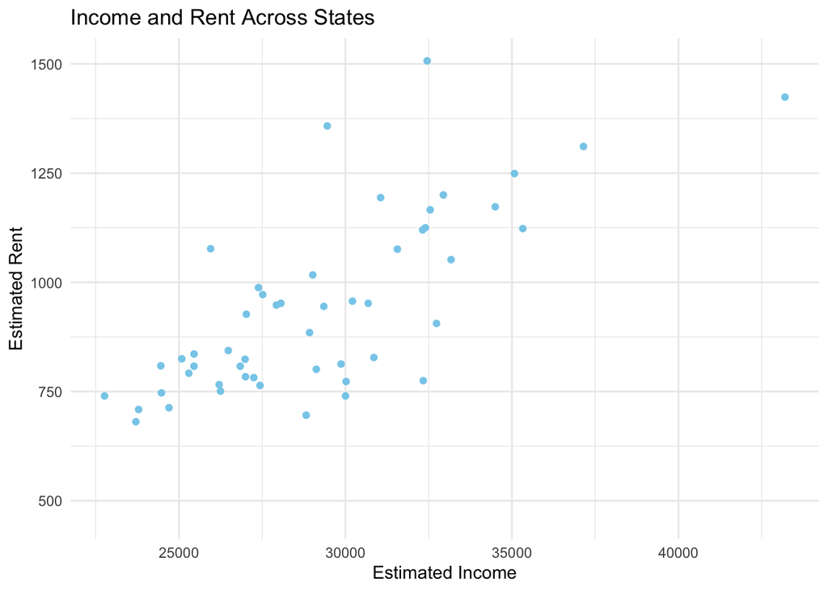

```r
# Visualize the relationship between income and rent
us_rent_income_wider |>
  ggplot(aes(x = estimate_income, y = estimate_rent)) +
  geom_point(color = "skyblue") +
  labs(
    title = "Income and Rent Across States",
    x = "Estimated Income",
    y = "Estimated Rent"
  ) +
  theme_minimal()
```

I also changed the scatterplot points to sky blue so the chart looks clearer and easier to read.

## 6.5 4.5 Reshape and visualize in one chain

**Question:** Repeat the previous reshaping and visualization in one long Tidyverse chain.

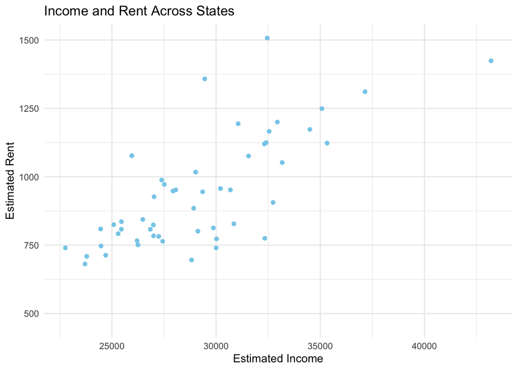

```r
# Reshape and visualize us_rent_income in one chain
us_rent_income |>
  pivot_wider(
    names_from = variable,
    values_from = c(estimate, moe)
  ) |>
  ggplot(aes(x = estimate_income, y = estimate_rent)) +
  geom_point(color = "skyblue") +
  labs(
    title = "Income and Rent Across States",
    x = "Estimated Income",
    y = "Estimated Rent"
  ) +
  theme_minimal()
```

# 7 Exercise 5

## 7.1 5.1 Separate the stats column

**Question:** Create the `mba` data frame and use `separate()` to split the stats column into points, assists, and steals.

```r
# Create the mba data frame
mba <- data.frame(
  player = c("A", "A", "B", "B", "C", "C"),
  year = c(1, 2, 1, 2, 1, 2),
  stats = c("22/2/3", "29/3/4", "18/6/7", "11/1/2", "12/1/1", "19/2/4")
)

# Separate stats into points, assists, and steals
mba_sep <- mba |>
  separate(
    col = stats,
    into = c("points", "assists", "steals"),
    sep = "/"
  )

# Print the separated data
mba_sep
```

| player | year | points | assists | steals |
| --- | --- | --- | --- | --- |
| A | 1 | 22 | 2 | 3 |
| A | 2 | 29 | 3 | 4 |
| B | 1 | 18 | 6 | 7 |
| B | 2 | 11 | 1 | 2 |
| C | 1 | 12 | 1 | 1 |
| C | 2 | 19 | 2 | 4 |

## 7.2 5.2 Unite the separated stats columns

**Question:** Use `unite()` to combine points, assists, and steals back into one stats column.

```r
# Unite points, assists, and steals back into one stats column
mba_uni <- mba_sep |>
  unite(
    col = stats,
    points,
    assists,
    steals,
    sep = "/"
  )

# Print the united data
mba_uni
```

| player | year | stats |
| --- | --- | --- |
| A | 1 | 22/2/3 |
| A | 2 | 29/3/4 |
| B | 1 | 18/6/7 |
| B | 2 | 11/1/2 |
| C | 1 | 12/1/1 |
| C | 2 | 19/2/4 |

# 8 Exercise 6

## 8.1 6.1 First and last departure times

**Question:** Filter for flights that were not canceled. For each day, calculate the first and last departure times from a NYC airport. Then, for each month, select one day where the first flight departure was latest for the month. Show the results in a nice table.

```r
# Load package and flights dataset
library(nycflights13)
data("flights")

# Find first and last departure times for each day
daily_departures <- flights |>
  filter(!is.na(dep_time)) |>
  group_by(year, month, day) |>
  summarize(
    first_dep = min(dep_time),
    last_dep = max(dep_time),
    n = n(),
    .groups = "drop"
  )

# Select one day each month where the first departure was latest
latest_first_departure <- daily_departures |>
  group_by(month) |>
  filter(first_dep == max(first_dep)) |>
  slice_head(n = 1) |>
  ungroup() |>
  arrange(desc(first_dep))

# Print the results
latest_first_departure
```

| year | month | day | first_dep | last_dep | n |
| --- | --- | --- | --- | --- | --- |
| 2013 | 2 | 9 | 901 | 2358 | 291 |
| 2013 | 1 | 20 | 525 | 2356 | 782 |
| 2013 | 9 | 29 | 521 | 2356 | 911 |
| 2013 | 10 | 6 | 519 | 2346 | 914 |
| 2013 | 11 | 3 | 519 | 2358 | 900 |
| 2013 | 3 | 3 | 509 | 2353 | 910 |
| 2013 | 12 | 18 | 500 | 2358 | 953 |
| 2013 | 5 | 29 | 457 | 2352 | 969 |
| 2013 | 6 | 15 | 456 | 2356 | 795 |
| 2013 | 4 | 30 | 455 | 2351 | 958 |

[output cut: 2 more lines]

```r
# Show results in a nice table
latest_first_departure |>
  gt() |>
  tab_header(
    title = "Latest First Departure Time by Month"
  )
```

Latest First Departure Time by Month

| year | month | day | first_dep | last_dep | n |
| --- | --- | --- | --- | --- | --- |
| 2013 | 2 | 9 | 901 | 2358 | 291 |
| 2013 | 1 | 20 | 525 | 2356 | 782 |
| 2013 | 9 | 29 | 521 | 2356 | 911 |
| 2013 | 10 | 6 | 519 | 2346 | 914 |
| 2013 | 11 | 3 | 519 | 2358 | 900 |
| 2013 | 3 | 3 | 509 | 2353 | 910 |
| 2013 | 12 | 18 | 500 | 2358 | 953 |
| 2013 | 5 | 29 | 457 | 2352 | 969 |
| 2013 | 6 | 15 | 456 | 2356 | 795 |
| 2013 | 4 | 30 | 455 | 2351 | 958 |
| 2013 | 8 | 31 | 455 | 2359 | 676 |
| 2013 | 7 | 5 | 38 | 2358 | 819 |

## 8.2 6.2 Top 5 destinations carriers flew the most

**Question:** Find the top 5 destinations that carriers flew to the most. Print the results in a nice table and explain whether the outcome makes sense.

```r
# Find the top 5 destinations
top_destinations <- flights |>
  count(dest, sort = TRUE) |>
  slice_head(n = 5)

# Print the results
top_destinations
```

| dest | n |
| --- | --- |
| ORD | 17283 |
| ATL | 17215 |
| LAX | 16174 |
| BOS | 15508 |
| MCO | 14082 |

```r
# Show results in a nice table
top_destinations |>
  gt() |>
  tab_header(
    title = "Top 5 Destinations by Number of Flights"
  )
```

Top 5 Destinations by Number of Flights

| dest | n |
| --- | --- |
| ORD | 17283 |
| ATL | 17215 |
| LAX | 16174 |
| BOS | 15508 |
| MCO | 14082 |

The results make sense because busy destinations usually have more flights. Bigger cities and popular routes are more likely to show up because more people travel to those places.

# 9 Exercise 7

## 9.1 7.1 Replace missing Solar.R values

**Question:** Find how many missing values exist in `Solar.R` and what percent of records are missing. Then replace the missing `Solar.R` values with the mean and confirm there are no more missing values.

```r
# Count missing values and percent missing for Solar.R
air.tib |>
  summarize(
    missing_Solar_R = sum(is.na(Solar.R)),
    percent_missing = mean(is.na(Solar.R)) * 100
  )
```

| missing_Solar_R | percent_missing |
| --- | --- |
| 7 | 4.575163 |

```r
# Find the mean of Solar.R
Solar_Mean <- mean(air.tib$Solar.R, na.rm = TRUE)

# Replace missing Solar.R values with the mean
air.tib <- air.tib |>
  mutate(
    Solar.R = if_else(is.na(Solar.R), Solar_Mean, Solar.R)
  )

# Confirm there are no more missing Solar.R values
air.tib |>
  summarize(
    missing_Solar_R = sum(is.na(Solar.R))
  )
```

| missing_Solar_R |
| --- |
| 0 |

I found 7 missing values in `Solar.R`, which is about 4.58% of the records. Then I replaced those missing values with the average Solar.R value and checked again to make sure there weren’t any missing values left.

# 10 Exercise 8

## 10.1 8.1 Visualize monthly total temperature

**Question:** Visualize monthly total temperature with a bar plot. Month should be on the y-axis and total temperature should be on the x-axis.

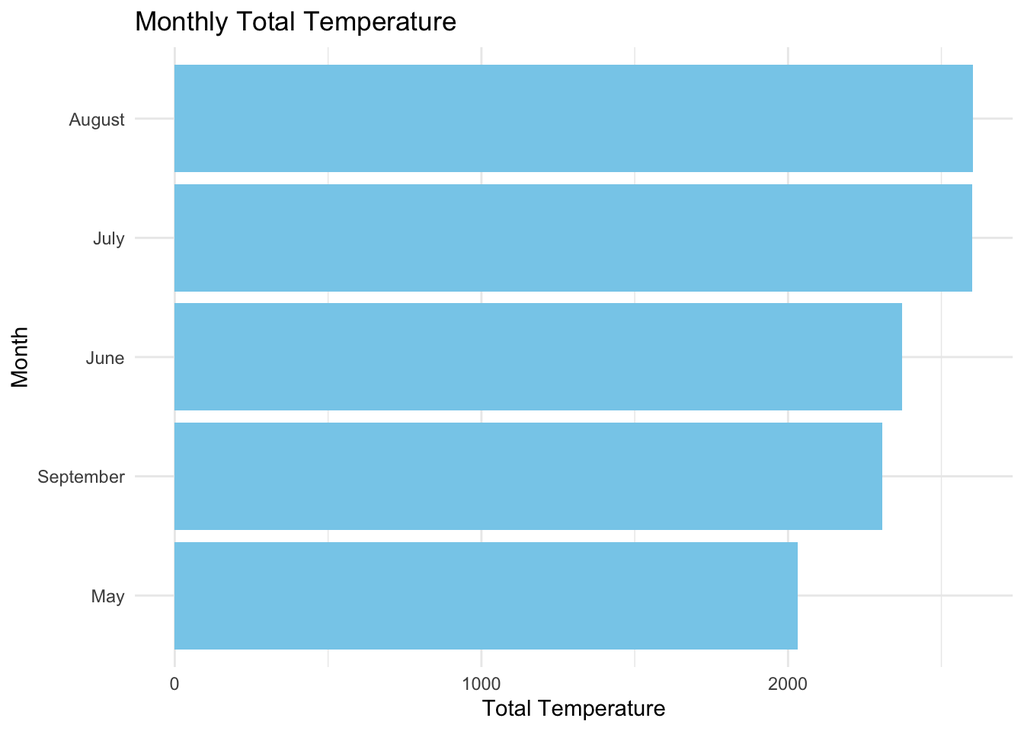

```r
# Visualize monthly total temperature
air.tib |>
  count(Month, wt = Temp, name = "total_temp") |>
  mutate(
    Month = case_when(
      Month == 5 ~ "May",
      Month == 6 ~ "June",
      Month == 7 ~ "July",
      Month == 8 ~ "August",
      Month == 9 ~ "September"
    ),
    Month = factor(Month),
    Month = fct_reorder(Month, total_temp)
  ) |>
  ggplot(aes(x = total_temp, y = Month)) +
  geom_col(fill = "skyblue") +
  labs(
    title = "Monthly Total Temperature",
    x = "Total Temperature",
    y = "Month"
  ) +
  theme_minimal()
```

This chart shows the total temperature for each month in the `air.tib` data. I changed the month numbers into month names so it’s easier to read.

# 11 Exercise 9

## 11.1 9.1 Visualize maximum temperature by month

**Question:** Group by Month, find the maximum Temp for each month, display the result, and create an appropriate chart.

```r
# Find maximum temperature for each month
monthly_max_temp <- air.tib |>
  group_by(Month) |>
  summarize(
    max_temp = max(Temp),
    .groups = "drop"
  )

# Print the monthly maximum temperatures
monthly_max_temp
```

| Month | max_temp |
| --- | --- |
| 5 | 81 |
| 6 | 93 |
| 7 | 92 |
| 8 | 97 |
| 9 | 93 |

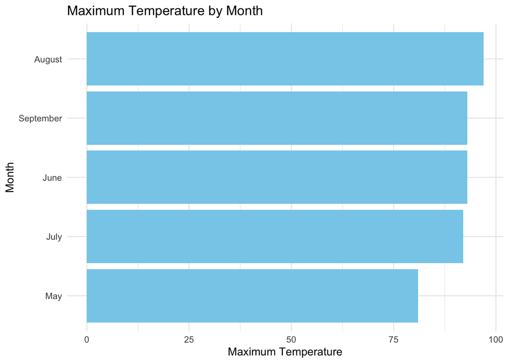

```r
# Visualize maximum temperature by month
monthly_max_temp |>
  mutate(
    Month = case_when(
      Month == 5 ~ "May",
      Month == 6 ~ "June",
      Month == 7 ~ "July",
      Month == 8 ~ "August",
      Month == 9 ~ "September"
    ),
    Month = factor(Month),
    Month = fct_reorder(Month, max_temp)
  ) |>
  ggplot(aes(x = max_temp, y = Month)) +
  geom_col(fill = "skyblue") +
  labs(
    title = "Maximum Temperature by Month",
    x = "Maximum Temperature",
    y = "Month"
  ) +
  theme_minimal()
```

This chart shows the highest temperature recorded for each month. I changed the month numbers into month names so it’s easier to understand.

# 12 Exercise 10

## 12.1 10.1 Explore Ozone, Wind, Temp, and temp_wind

**Question:** Create a new column called `temp_wind`, then investigate the relationship between Ozone and temp_wind. Also visualize Wind vs Ozone and Wind vs Temp. Show all three relationships in one chart.

```r
# Create temp_wind and reshape data for the chart
air_relationships <- air.tib |>
  mutate(
    temp_wind = Temp / Wind
  ) |>
  select(Ozone, Wind, Temp, temp_wind) |>
  pivot_longer(
    cols = c(Wind, Temp, temp_wind),
    names_to = "variable",
    values_to = "value"
  )

# Print the reshaped data
air_relationships
```

| Ozone | variable | value |
| --- | --- | --- |
| 41 | Wind | 7.400000 |
| 41 | Temp | 67.000000 |
| 41 | temp_wind | 9.054054 |
| 36 | Wind | 8.000000 |
| 36 | Temp | 72.000000 |
| 36 | temp_wind | 9.000000 |
| 12 | Wind | 12.600000 |
| 12 | Temp | 74.000000 |
| 12 | temp_wind | 5.873016 |
| 18 | Wind | 11.500000 |

[output cut: 449 more lines]

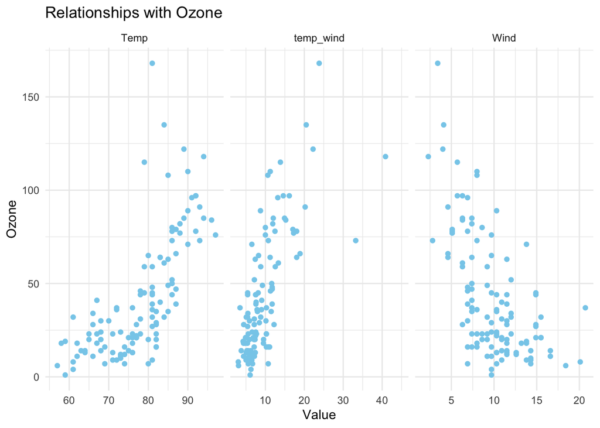

```r
# Visualize the relationships
air_relationships |>
  ggplot(aes(x = value, y = Ozone)) +
  geom_point(color = "skyblue") +
  facet_wrap(~ variable, scales = "free_x") +
  labs(
    title = "Relationships with Ozone",
    x = "Value",
    y = "Ozone"
  ) +
  theme_minimal()
```

This chart helps me compare how Ozone connects to Wind, Temp, and temp_wind. From the plots, temp_wind seems to have a stronger connection with Ozone than Wind or Temp do by themselves.